# ESTADISTICA PARA EL ANALISIS POLITICO II

- Profesor: [Dr. José Manuel Magallanes, Ph.D.](http://www.pucp.edu.pe/profesor/jose-manuel-magallanes/)
  - Profesor del Departamento de Ciencias Sociales, Sección de Ciencia Política y Gobierno.
  - [Oficina 105](https://goo.gl/maps/xuGeG6o9di1i1y5m6) - Edificio CISEPA / ECONOMIA / CCSS
  - Telefono: (51) 1 - 6262000 anexo 4302
  - Correo Electrónico: jmagallanes@pucp.edu.pe

## 1. Regresión Tobit

Veamos estos resultados academicos:

[interactive chart not shown]

Se desea probar la relación del nivel de matemática, lectura y del tipo de programa escolar, en el nivel obtenido en un test de ingreso a la universidad. El test va de 200 a 800.

Traigamos la data:

```r
link="https://docs.google.com/spreadsheets/d/e/2PACX-1vS52b1wXYlsPgZ5o0Vw6cooy6nNQe7lsTsHF_AO1DhMbgxiM1xlWXepapodzpUhmuBzhK2mO7SX3LtB/pub?gid=0&single=true&output=csv"

escuela = read.csv(link)
```

Aquí corresponde una regresión Tobit.

```r
library(VGAM)

escuela_tobit <- VGAM::vglm(apt ~ ., tobit(Upper = 800), data = escuela)
summary(escuela_tobit)
```

```
##
## Call:
## VGAM::vglm(formula = apt ~ ., family = tobit(Upper = 800), data = escuela)
##
## Pearson residuals:
##                 Min      1Q   Median     3Q   Max
## mu          -2.5352 -0.7114 -0.02159 0.7461 2.867
## loglink(sd) -0.9829 -0.6382 -0.34056 0.2615 5.106
##
## Coefficients:
##                 Estimate Std. Error z value Pr(>|z|)
## (Intercept):1  207.59611   32.66324   6.356 2.08e-10 ***
## (Intercept):2    4.18420    0.05234  79.936  < 2e-16 ***
## id               0.04812    0.08317   0.579 0.562893
## read             2.69820    0.61875   4.361 1.30e-05 ***
## math             5.86025    0.71215   8.229  < 2e-16 ***
## proggeneral    -12.83540   12.40323  -1.035 0.300742
## progvocational -45.91638   13.70316  -3.351 0.000806 ***
## ---
## Signif. codes:  0 '***' 0.001 '**' 0.01 '*' 0.05 '.' 0.1 ' ' 1
##
## Names of linear predictors: mu, loglink(sd)
##
## Log-likelihood: -1040.896 on 393 degrees of freedom
##
## Number of Fisher scoring iterations: 6
##
## No Hauck-Donner effect found in any of the estimates
```

## 2. Regresión Poisson

Veamos algo de la situación de las familias en las Filipinas:

[interactive chart not shown]

Se desea tener como dependiente al numero de miembros de la familia que trabaja sin considerar al jefe de familia, y a las demas variables como predictoras.

```r
link="https://docs.google.com/spreadsheets/d/e/2PACX-1vSndImAy2ys7_-PMxNNq44OkwbjGikrigB32lBM0co-JOz0e2P8zBkAc6bqxTAB8Cg9mnV-VUcvMn-p/pub?gid=0&single=true&output=csv"
casa=read.csv(link)
```

```r
summary(casa)
```

```
##                 Main_Source_of_Income Education_Expenditure
##  Enterpreneurial Activities:10320     Min.   :     0
##  Other sources of Income   :10836     1st Qu.:     0
##  Wage/Salaries             :20388     Median :   880
##                                       Mean   :  7474
##                                       3rd Qu.:  4060
##                                       Max.   :731000
##  Household_Head_Sex Household_Head_Age Total_members_employed
##  Female: 9061       Min.   : 9.00      Min.   :0.000
##  Male  :32483       1st Qu.:41.00      1st Qu.:0.000
##                     Median :51.00      Median :1.000
##                     Mean   :51.38      Mean   :1.273
##                     3rd Qu.:61.00      3rd Qu.:2.000
##                     Max.   :99.00      Max.   :8.000
```

```r
casa_poisson=glm(Total_members_employed~.,family = poisson, data=casa)
summary(casa_poisson)
```

```
##
## Call:
## glm(formula = Total_members_employed ~ ., family = poisson, data = casa)
##
## Deviance Residuals:
##     Min       1Q   Median       3Q      Max
## -2.2398  -1.0512  -0.0334   0.4332   5.2074
##
## Coefficients:
##                                                Estimate Std. Error z value
## (Intercept)                                  -8.545e-01  2.511e-02 -34.028
## Main_Source_of_IncomeOther sources of Income  2.393e-01  1.731e-02  13.825
## Main_Source_of_IncomeWage/Salaries            1.174e+00  1.381e-02  84.980
## Education_Expenditure                         1.676e-06  1.781e-07   9.408
## Household_Head_SexMale                        1.072e-01  1.163e-02   9.219
## Household_Head_Age                            4.396e-03  3.361e-04  13.079
##                                              Pr(>|z|)
## (Intercept)                                    <2e-16 ***
## Main_Source_of_IncomeOther sources of Income   <2e-16 ***
## Main_Source_of_IncomeWage/Salaries             <2e-16 ***
## Education_Expenditure                          <2e-16 ***
## Household_Head_SexMale                         <2e-16 ***
## Household_Head_Age                             <2e-16 ***
## ---
## Signif. codes:  0 '***' 0.001 '**' 0.01 '*' 0.05 '.' 0.1 ' ' 1
##
## (Dispersion parameter for poisson family taken to be 1)
##
##     Null deviance: 48553  on 41543  degrees of freedom
## Residual deviance: 35507  on 41538  degrees of freedom
## AIC: 107388
##
## Number of Fisher Scoring iterations: 5
```

```r
exp(confint(casa_poisson))
```

```
##                                                  2.5 %    97.5 %
## (Intercept)                                  0.4050165 0.4469158
## Main_Source_of_IncomeOther sources of Income 1.2279657 1.3141660
## Main_Source_of_IncomeWage/Salaries           3.1485379 3.3237454
## Education_Expenditure                        1.0000013 1.0000020
## Household_Head_SexMale                       1.0881050 1.1388416
## Household_Head_Age                           1.0037438 1.0050670
```

Una cosa muy importante: ¿Habrá sobre dispersion?

```r
#library(AER)
AER::dispersiontest(casa_poisson,trafo=1)
```

```
##
##  Overdispersion test
##
## data:  casa_poisson
## z = -17.051, p-value = 1
## alternative hypothesis: true alpha is greater than 0
## sample estimates:
##      alpha
## -0.1365553
```

## 3. Regresión Ordinal

Traigamos varios indicadores e indices de Perú:

[interactive chart not shown]

```r
link='https://docs.google.com/spreadsheets/d/e/2PACX-1vRIELLZGB7UZfNMSHmPExFW6BsCwjWvCcNJV4uvjRd9Tnwq0DqveCBOhJhKwWaRxtPedAxrI6rHY9Ps/pub?gid=550147750&single=true&output=csv'

perudat=read.csv(link, stringsAsFactors = F)
names(perudat)
```

```
##  [1] "NOMBDEP"    "NOMBPROV"   "IDH"        "esperanza"  "secundaria"
##  [6] "educa"      "percapitaf" "IDE"        "identidad"  "salud"
## [11] "educacion"  "saneamient" "electrific" "poblacion"  "costa"
## [16] "capital"    "tamano"     "fecundidad" "desnutrici" "densidadpo"
## [21] "mortalidad" "analfa"     "analfa_ur"  "analfa_ru"  "analfa_h"
## [26] "analfa_m"   "pob"        "pob_ur"     "pob_rural"  "pob_h"
## [31] "pob_m"      "Voto_PPK"   "Voto_FP"
```

Creemos una **variable dependiente ordinal** a partir del indice IDH:

```r
niveles=c('muy baja','baja','media',"alta",'muy alta')

perudat$IDHord=cut(perudat$IDH,
                    breaks = length(niveles),
                    labels = niveles,
                    ordered_result = T)
```

```r
# podemos querer explicar el nivel de IDH
# 1-segun cada componente del IDE menos educacion
# 2-estar en la costa
sub1=c("IDHord","identidad",  "salud","educacion","saneamient","electrific","costa")
reg1Data=perudat[,sub1]
names(reg1Data)
```

```
## [1] "IDHord"     "identidad"  "salud"      "educacion"  "saneamient"
## [6] "electrific" "costa"
```

```r
reg1Data$costa <- as.factor(reg1Data$costa)
table(reg1Data$costa)
```

```
##
##  NO  SI
## 163  32
```

```r
library("oglmx")
modelOrd=ologit.reg(IDHord ~ .,
                  data = reg1Data)
summary(modelOrd)
```

```
## Ordered Logit Regression
## Log-Likelihood: -133.2849
## No. Iterations: 7
## McFadden's R2: 0.5375673
## AIC: 286.5697
##             Estimate Std. error t value  Pr(>|t|)
## identidad  -0.385919   0.088973 -4.3375 1.441e-05 ***
## salud       0.256748   0.038867  6.6058 3.953e-11 ***
## educacion   0.136587   0.025126  5.4362 5.444e-08 ***
## saneamient  0.026059   0.012823  2.0322   0.04213 *
## electrific  0.086316   0.018570  4.6482 3.348e-06 ***
## costaSI     4.576322   0.812770  5.6305 1.797e-08 ***
## ----- Threshold Parameters -----
##                            Estimate Std. error t value Pr(>|t|)
## Threshold (muy baja->baja) -18.8574     7.3087 -2.5801 0.009876 **
## Threshold (baja->media)    -14.8535     7.2468 -2.0497 0.040397 *
## Threshold (media->alta)    -11.6483     7.2181 -1.6138 0.106581
## Threshold (alta->muy alta)  -5.0902     7.1421 -0.7127 0.476033
## ---
## Signif. codes:  0 '***' 0.001 '**' 0.01 '*' 0.05 '.' 0.1 ' ' 1
```

```r
(modelOrd_M=margins.oglmx(modelOrd,ascontinuous = TRUE))
```

```
## Marginal Effects on Pr(Outcome==muy baja)
##              Marg. Eff  Std. error t value Pr(>|t|)
## identidad   0.00830654  0.00321049  2.5873 0.009673 **
## salud      -0.00552627  0.00182609 -3.0263 0.002476 **
## educacion  -0.00293992  0.00104810 -2.8050 0.005032 **
## saneamient -0.00056090  0.00031564 -1.7770 0.075561 .
## electrific -0.00185788  0.00070365 -2.6404 0.008282 **
## costaSI    -0.09850114  0.03257749 -3.0236 0.002498 **
## ------------------------------------
## Marginal Effects on Pr(Outcome==baja)
##             Marg. Eff Std. error t value  Pr(>|t|)
## identidad   0.0871187  0.0214081  4.0694 4.713e-05 ***
## salud      -0.0579594  0.0106194 -5.4579 4.818e-08 ***
## educacion  -0.0308337  0.0062841 -4.9066 9.265e-07 ***
## saneamient -0.0058827  0.0029446 -1.9978   0.04574 *
## electrific -0.0194854  0.0044590 -4.3699 1.243e-05 ***
## costaSI    -1.0330766  0.2192734 -4.7114 2.461e-06 ***
## ------------------------------------
## Marginal Effects on Pr(Outcome==media)
##             Marg. Eff Std. error t value  Pr(>|t|)
## identidad  -0.0835332  0.0209797 -3.9816 6.845e-05 ***
## salud       0.0555739  0.0102944  5.3985 6.721e-08 ***
## educacion   0.0295647  0.0061971  4.7707 1.836e-06 ***
## saneamient  0.0056406  0.0028448  1.9828   0.04739 *
## electrific  0.0186834  0.0044398  4.2082 2.575e-05 ***
## costaSI     0.9905582  0.2099135  4.7189 2.371e-06 ***
## ------------------------------------
## Marginal Effects on Pr(Outcome==alta)
##              Marg. Eff  Std. error t value Pr(>|t|)
## identidad  -0.01187410  0.00503387 -2.3588  0.01833 *
## salud       0.00789974  0.00313318  2.5213  0.01169 *
## educacion   0.00420257  0.00168372  2.4960  0.01256 *
## saneamient  0.00080180  0.00047169  1.6999  0.08916 .
## electrific  0.00265581  0.00107277  2.4756  0.01330 *
## costaSI     0.14080612  0.05758095  2.4454  0.01447 *
## ------------------------------------
## Marginal Effects on Pr(Outcome==muy alta)
##              Marg. Eff  Std. error t value Pr(>|t|)
## identidad  -1.7996e-05  1.8914e-05 -0.9514   0.3414
## salud       1.1972e-05  1.2263e-05  0.9763   0.3289
## educacion   6.3692e-06  6.6614e-06  0.9561   0.3390
## saneamient  1.2152e-06  1.3739e-06  0.8845   0.3764
## electrific  4.0250e-06  4.2970e-06  0.9367   0.3489
## costaSI     2.1340e-04  2.1274e-04  1.0031   0.3158
```

## 4. Regresión Beta

Veamos una numérica porcentual:

```r
# como se comporta la mortalidad?
summary(perudat$mortalidad)
```

```
##    Min. 1st Qu.  Median    Mean 3rd Qu.    Max.
##     9.2    18.2    23.0    23.9    28.4    52.1
```

Transformemosla en (0,1):

```r
perudat$mortalidad=perudat$mortalidad/100
```

```r
library(betareg)
#VD:mortalidad
#VIs:desnutrici, percapitaf, salud, saneamient, analfa
#VCs:población
sub2=c('mortalidad','desnutrici', 'percapitaf', 'salud', 'saneamient', 'analfa','pob')
reg2Data=perudat[,sub2]
modelBeta=betareg(mortalidad~.,data=reg2Data)
summary(modelBeta)
```

```
##
## Call:
## betareg(formula = mortalidad ~ ., data = reg2Data)
##
## Standardized weighted residuals 2:
##     Min      1Q  Median      3Q     Max
## -2.3381 -0.6832 -0.0967  0.6679  3.0430
##
## Coefficients (mean model with logit link):
##               Estimate Std. Error z value Pr(>|z|)
## (Intercept) -8.493e-01  1.996e-01  -4.255 2.09e-05 ***
## desnutrici   7.319e-03  2.616e-03   2.797  0.00515 **
## percapitaf  -1.675e-03  6.186e-04  -2.708  0.00676 **
## salud       -1.095e-02  5.510e-03  -1.987  0.04693 *
## saneamient  -9.630e-04  1.791e-03  -0.538  0.59083
## analfa       3.863e-04  4.896e-03   0.079  0.93711
## pob          3.883e-08  5.903e-08   0.658  0.51062
##
## Phi coefficients (precision model with identity link):
##       Estimate Std. Error z value Pr(>|z|)
## (phi)   47.564      4.784   9.943   <2e-16 ***
## ---
## Signif. codes:  0 '***' 0.001 '**' 0.01 '*' 0.05 '.' 0.1 ' ' 1
##
## Type of estimator: ML (maximum likelihood)
## Log-likelihood: 273.6 on 8 Df
## Pseudo R-squared: 0.485
## Number of iterations: 18 (BFGS) + 2 (Fisher scoring)
```

## 5. Ecuaciones Estructurales:

1. Representar modelo:

```r
modelo=
        'ideL =~ identidad + salud + educacion + saneamient + electrific
        idhL =~ esperanza + secundaria + educa +percapitaf
        vulL =~ fecundidad + desnutrici + mortalidad

        # regresiones
        idhL ~ ideL + vulL+ costa'
```

2. Reformatear “character” como numérico (via factor):

```r
perudat$costa=as.numeric(as.factor(perudat$costa))
```

3. Calcular

```r
library(lavaan)

# Calculos
perudat=scale(perudat[,-c(1,2,16:17,34)])
regLat1<-sem(modelo, data=perudat, fixed.x=FALSE)
```

Estos son los resultados:

- Regresiones

```r
library(knitr)
allParamSEM=parameterEstimates(regLat1,standardized = T)

kable(allParamSEM[allParamSEM$op=="~",])
```

|  | lhs | op | rhs | est | se | z | pvalue | ci.lower | ci.upper | std.lv | std.all | std.nox |
| --- | --- | --- | --- | --- | --- | --- | --- | --- | --- | --- | --- | --- |
| 13 | idhL | ~ | ideL | 0.8366069 | 0.2094617 | 3.994081 | 0.0000649 | 0.4260695 | 1.2471442 | 0.6763739 | 0.6763739 | 0.6763739 |
| 14 | idhL | ~ | vulL | -0.2978926 | 0.1328352 | -2.242573 | 0.0249244 | -0.5582449 | -0.0375404 | -0.3129578 | -0.3129578 | -0.3129578 |
| 15 | idhL | ~ | costa | 0.1091277 | 0.0214360 | 5.090853 | 0.0000004 | 0.0671139 | 0.1511416 | 0.1778890 | 0.1774323 | 0.1778890 |

- Cargas

```r
kable(allParamSEM[allParamSEM$op=="=~",])
```

| lhs | op | rhs | est | se | z | pvalue | ci.lower | ci.upper | std.lv | std.all | std.nox |
| --- | --- | --- | --- | --- | --- | --- | --- | --- | --- | --- | --- |
| ideL | =~ | identidad | 1.000000 | 0.0000000 | NA | NA | 1.0000000 | 1.000000 | 0.4959656 | 0.4972420 | 0.4972420 |
| ideL | =~ | salud | 1.487895 | 0.2176529 | 6.836093 | 0 | 1.0613034 | 1.914487 | 0.7379448 | 0.7398436 | 0.7398436 |
| ideL | =~ | educacion | 1.427351 | 0.2129877 | 6.701563 | 0 | 1.0099023 | 1.844799 | 0.7079168 | 0.7097379 | 0.7097379 |
| ideL | =~ | saneamient | 1.516657 | 0.2199028 | 6.896945 | 0 | 1.0856559 | 1.947659 | 0.7522099 | 0.7541457 | 0.7541457 |
| ideL | =~ | electrific | 1.664483 | 0.2318067 | 7.180481 | 0 | 1.2101506 | 2.118816 | 0.8255265 | 0.8276510 | 0.8276510 |
| idhL | =~ | esperanza | 1.000000 | 0.0000000 | NA | NA | 1.0000000 | 1.000000 | 0.6134598 | 0.6392664 | 0.6392664 |
| idhL | =~ | secundaria | 1.244240 | 0.1279236 | 9.726430 | 0 | 0.9935146 | 1.494966 | 0.7632914 | 0.8135133 | 0.8135133 |
| idhL | =~ | educa | 1.392287 | 0.1301880 | 10.694434 | 0 | 1.1371232 | 1.647451 | 0.8541121 | 0.9256170 | 0.9256170 |
| idhL | =~ | percapitaf | 1.375099 | 0.1298788 | 10.587556 | 0 | 1.1205413 | 1.629657 | 0.8435680 | 0.9123070 | 0.9123070 |
| vulL | =~ | fecundidad | 1.000000 | 0.0000000 | NA | NA | 1.0000000 | 1.000000 | 0.6444839 | 0.6461428 | 0.6461428 |
| vulL | =~ | desnutrici | 1.341609 | 0.1360593 | 9.860474 | 0 | 1.0749375 | 1.608280 | 0.8646453 | 0.8668708 | 0.8668708 |
| vulL | =~ | mortalidad | 1.053775 | 0.1281154 | 8.225200 | 0 | 0.8026730 | 1.304876 | 0.6791407 | 0.6808885 | 0.6808885 |

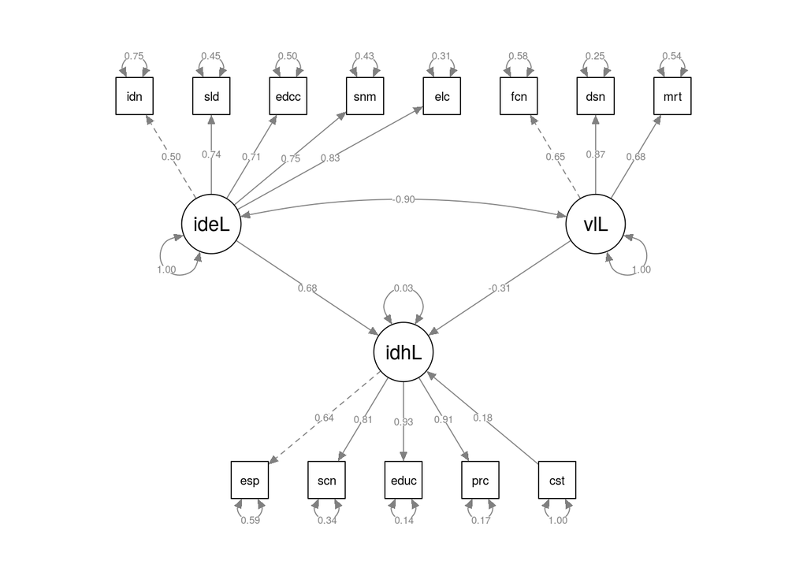

```r
library(semPlot)
semPaths(regLat1 ,layout='tree2',whatLabels = 'std')
```

```r
modelo2=
        'ideL =~ identidad + salud + educacion + saneamient + electrific
        idhL =~ esperanza + secundaria + educa +percapitaf
        vulL =~ fecundidad + desnutrici + mortalidad

        # regresiones
        idhL ~ ideL
        ideL ~ vulL + costa'

# 2. Calculos

regLat2<-sem(modelo2, data=perudat)#, fixed.x=FALSE)
```

```r
# 2. Calculos

regLat2<-sem(modelo2, data=perudat, fixed.x=FALSE)
```

Estos son los resultados:

- Regresiones

```r
allParamSEM=parameterEstimates(regLat2,standardized = T)

kable(allParamSEM[allParamSEM$op=="~",])
```

|  | lhs | op | rhs | est | se | z | pvalue | ci.lower | ci.upper | std.lv | std.all | std.nox |
| --- | --- | --- | --- | --- | --- | --- | --- | --- | --- | --- | --- | --- |
| 13 | idhL | ~ | ideL | 1.4353822 | 0.2622240 | 5.473879 | 0.00e+00 | 0.9214327 | 1.9493317 | 0.9999004 | 0.9999004 | 0.9999004 |
| 14 | ideL | ~ | vulL | -0.5616611 | 0.1044799 | -5.375784 | 1.00e-07 | -0.7664378 | -0.3568843 | -0.8829782 | -0.8829782 | -0.8829782 |
| 15 | ideL | ~ | costa | 0.1035280 | 0.0239843 | 4.316493 | 1.59e-05 | 0.0565197 | 0.1505363 | 0.2499423 | 0.2493006 | 0.2499423 |

- Cargas

```r
kable(allParamSEM[allParamSEM$op=="=~",])
```

| lhs | op | rhs | est | se | z | pvalue | ci.lower | ci.upper | std.lv | std.all | std.nox |
| --- | --- | --- | --- | --- | --- | --- | --- | --- | --- | --- | --- |
| ideL | =~ | identidad | 1.000000 | 0.0000000 | NA | NA | 1.0000000 | 1.000000 | 0.4142076 | 0.4240204 | 0.4240204 |
| ideL | =~ | salud | 1.604826 | 0.2783012 | 5.766508 | 0 | 1.0593657 | 2.150286 | 0.6647310 | 0.7045148 | 0.7045148 |
| ideL | =~ | educacion | 1.467467 | 0.2643354 | 5.551533 | 0 | 0.9493789 | 1.985555 | 0.6078358 | 0.6380983 | 0.6380983 |
| ideL | =~ | saneamient | 1.634154 | 0.2813501 | 5.808259 | 0 | 1.0827183 | 2.185590 | 0.6768791 | 0.7189485 | 0.7189485 |
| ideL | =~ | electrific | 1.727718 | 0.2912201 | 5.932690 | 0 | 1.1569376 | 2.298499 | 0.7156341 | 0.7656517 | 0.7656517 |
| idhL | =~ | esperanza | 1.000000 | 0.0000000 | NA | NA | 1.0000000 | 1.000000 | 0.5946054 | 0.6229132 | 0.6229132 |
| idhL | =~ | secundaria | 1.269022 | 0.1348729 | 9.409019 | 0 | 1.0046758 | 1.533368 | 0.7545673 | 0.8136293 | 0.8136293 |
| idhL | =~ | educa | 1.418686 | 0.1378503 | 10.291501 | 0 | 1.1485049 | 1.688868 | 0.8435587 | 0.9279277 | 0.9279277 |
| idhL | =~ | percapitaf | 1.392254 | 0.1372463 | 10.144205 | 0 | 1.1232568 | 1.661252 | 0.8278421 | 0.9072345 | 0.9072345 |
| vulL | =~ | fecundidad | 1.000000 | 0.0000000 | NA | NA | 1.0000000 | 1.000000 | 0.6511689 | 0.6528454 | 0.6528454 |
| vulL | =~ | desnutrici | 1.325662 | 0.1348534 | 9.830399 | 0 | 1.0613547 | 1.589970 | 0.8632302 | 0.8654526 | 0.8654526 |
| vulL | =~ | mortalidad | 1.035466 | 0.1266484 | 8.175914 | 0 | 0.7872401 | 1.283693 | 0.6742635 | 0.6759998 | 0.6759998 |

Visualmente:

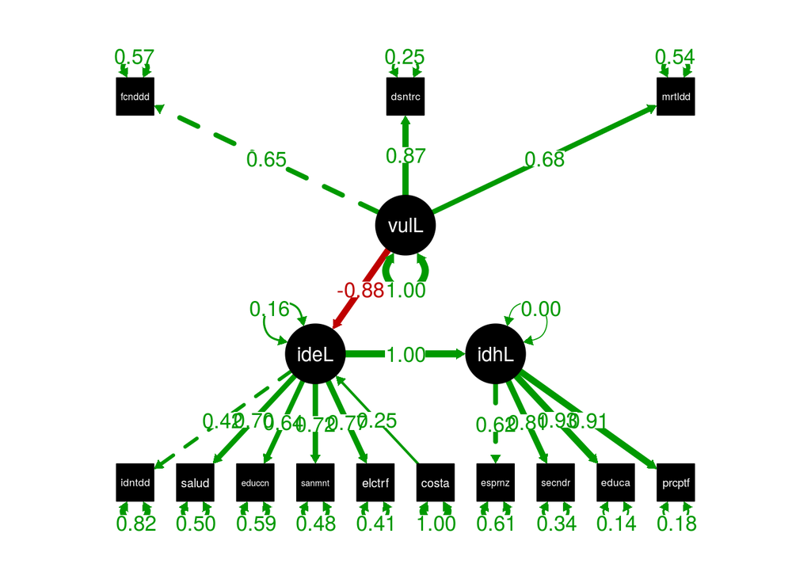

```r
semPaths(regLat2, what='std', nCharNodes=6, sizeMan=5,
         edge.label.cex=1.25, curvePivot = TRUE, fade=FALSE,color='black')
```

Qué tan bueno es el modelo?

```r
allFitSEM=as.list(fitMeasures(regLat2))
```

```r
allFitSEM[c("chisq", "df", "pvalue")] # pvalue>0.05
```

```
## $chisq
## [1] 1423.671
##
## $df
## [1] 63
##
## $pvalue
## [1] 0
```

- El Índice Tucker Lewi es mayor a 0.9?

```r
allFitSEM$tli # > 0.90
```

```
## [1] 0.4343883
```

- La Raíz del error cuadrático medio de aproximación es menor a 0.05?

```r
allFitSEM[c( 'rmsea.ci.lower','rmsea','rmsea.ci.upper')] #  toca 0.08
```

```
## $rmsea.ci.lower
## [1] 0.3179123
##
## $rmsea
## [1] 0.3328044
##
## $rmsea.ci.upper
## [1] 0.3479291
```

al INICIO

[VOLVER A CONTENIDOS](https://politicaygobiernopucp.github.io/estadistica_anapol2/)